# Project Introduction to Computer Vision

## 4. Data Pre-Processing

### 4.1 Gaussian Blur and Normalization

First, we are going to use Gaussian Blurring to remove unwanted noise from the images. We are also going to normalize data between range 0 to 1 dividing by 255

```python
# create empty array
data_blur = np.empty(shape=(4750, 128, 128, 3),dtype='float32')
# use gaussian blurring and normalization
for img in range(len(data)):
    data_blur[img] = cv2.GaussianBlur(data[img], (5, 5), 0) / 255.0
```

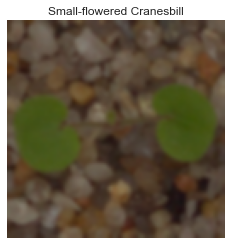

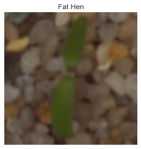

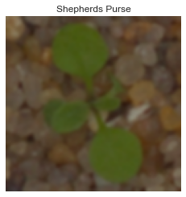

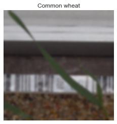

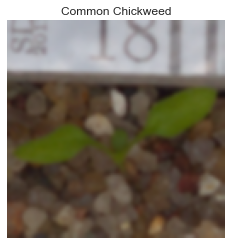

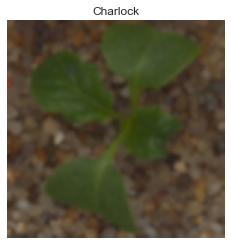

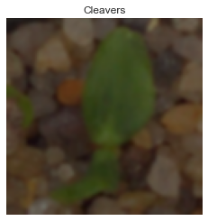

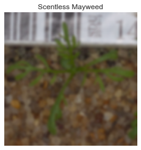

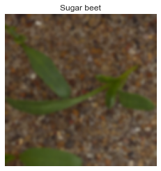

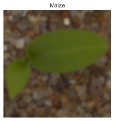

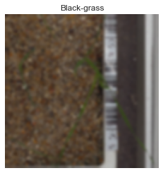

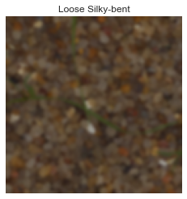

```python
# visualize first image in each group
for label in label_groups:
    img = cv2.cvtColor(data_blur[labels[labels['Label'] == label].index[0]] , cv2.COLOR_BGR2RGB)
    plt.figure()
    plt.title(label)
    plt.imshow(img)
    plt.axis('off')
```

### 4.2 Convert labels to one hot vector

```python
# replace '-' and ' ' character in labels
label = labels['Label'].str.replace('-', '', regex=True).str.replace(' ', '', regex=True)
# one-hot encoding
y = to_categorical(np.asarray(label.factorize()[0]))
```

```python
# print y
y
```

```
array([[1., 0., 0., ..., 0., 0., 0.],
       [1., 0., 0., ..., 0., 0., 0.],
       [1., 0., 0., ..., 0., 0., 0.],
       ...,
       [0., 0., 0., ..., 0., 0., 1.],
       [0., 0., 0., ..., 0., 0., 1.],
       [0., 0., 0., ..., 0., 0., 1.]], dtype=float32)
```

```python
# check shape
y.shape
```

```
(4750, 12)
```

- labels are now an array of 12 columns where 1 represents the correspondent plant

```python
# labels number
lbln = pd.DataFrame(np.asarray(label.factorize()[0]),columns = ['labels'])
lbl_dict = {ix:label[lbln['labels']==ix].iloc[0] for ix in range(12)}
lbl_dict
```

```
{0: 'SmallfloweredCranesbill',
 1: 'FatHen',
 2: 'ShepherdsPurse',
 3: 'Commonwheat',
 4: 'CommonChickweed',
 5: 'Charlock',
 6: 'Cleavers',
 7: 'ScentlessMayweed',
 8: 'Sugarbeet',
 9: 'Maize',
 10: 'Blackgrass',
 11: 'LooseSilkybent'}
```

### 4.3 Split data into train and test

```python
# Splitting data into training, validation and test set:
# first we split data into 2 parts, say temporary and test
X_temp, X_test, y_temp, y_test = train_test_split(data_blur, y, test_size=0.2, random_state=1, stratify=y)

# then we split the temporary set into train and validation
X_train, X_val, y_train, y_val = train_test_split(X_temp, y_temp, test_size=0.25, random_state=1, stratify=y_temp)

print(f'Shape of Training set: {X_train.shape}')
print(f'Shape of Validation set: {X_val.shape}')
print(f'Shape of Test set: {X_test.shape}')
print(f'Percentage of classes in Training set\n{pd.DataFrame(y_train).value_counts(normalize=True)}')
print(f'Percentage of classes in Validation set\n{pd.DataFrame(y_val).value_counts(normalize=True)}')
print(f'Percentage of classes in Test set\n{pd.DataFrame(y_test).value_counts(normalize=True)}')
```

```
Shape of Training set: (2850, 128, 128, 3)
Shape of Validation set: (950, 128, 128, 3)
Shape of Test set: (950, 128, 128, 3)
Percentage of classes in Training set
0    1    2    3    4    5    6    7    8    9    10   11
0.0  0.0  0.0  0.0  0.0  0.0  0.0  0.0  0.0  0.0  0.0  1.0    0.137544
                    1.0  0.0  0.0  0.0  0.0  0.0  0.0  0.0    0.128772
                    0.0  0.0  0.0  1.0  0.0  0.0  0.0  0.0    0.108772
1.0  0.0  0.0  0.0  0.0  0.0  0.0  0.0  0.0  0.0  0.0  0.0    0.104561
0.0  1.0  0.0  0.0  0.0  0.0  0.0  0.0  0.0  0.0  0.0  0.0    0.100000
     0.0  0.0  0.0  0.0  1.0  0.0  0.0  0.0  0.0  0.0  0.0    0.082105
                         0.0  0.0  0.0  1.0  0.0  0.0  0.0    0.081053
                              1.0  0.0  0.0  0.0  0.0  0.0    0.060351
                              0.0  0.0  0.0  0.0  1.0  0.0    0.055088
          1.0  0.0  0.0  0.0  0.0  0.0  0.0  0.0  0.0  0.0    0.048421
          0.0  0.0  0.0  0.0  0.0  0.0  0.0  1.0  0.0  0.0    0.046667
               1.0  0.0  0.0  0.0  0.0  0.0  0.0  0.0  0.0    0.046667
dtype: float64
Percentage of classes in Validation set
0    1    2    3    4    5    6    7    8    9    10   11
0.0  0.0  0.0  0.0  0.0  0.0  0.0  0.0  0.0  0.0  0.0  1.0    0.137895
                    1.0  0.0  0.0  0.0  0.0  0.0  0.0  0.0    0.128421
                    0.0  0.0  0.0  1.0  0.0  0.0  0.0  0.0    0.108421
1.0  0.0  0.0  0.0  0.0  0.0  0.0  0.0  0.0  0.0  0.0  0.0    0.104211
0.0  1.0  0.0  0.0  0.0  0.0  0.0  0.0  0.0  0.0  0.0  0.0    0.100000
     0.0  0.0  0.0  0.0  1.0  0.0  0.0  0.0  0.0  0.0  0.0    0.082105
                         0.0  0.0  0.0  1.0  0.0  0.0  0.0    0.081053
                              1.0  0.0  0.0  0.0  0.0  0.0    0.060000
                              0.0  0.0  0.0  0.0  1.0  0.0    0.055789
          1.0  0.0  0.0  0.0  0.0  0.0  0.0  0.0  0.0  0.0    0.049474
          0.0  0.0  0.0  0.0  0.0  0.0  0.0  1.0  0.0  0.0    0.046316
               1.0  0.0  0.0  0.0  0.0  0.0  0.0  0.0  0.0    0.046316
dtype: float64
Percentage of classes in Test set
0    1    2    3    4    5    6    7    8    9    10   11
0.0  0.0  0.0  0.0  0.0  0.0  0.0  0.0  0.0  0.0  0.0  1.0    0.137895
                    1.0  0.0  0.0  0.0  0.0  0.0  0.0  0.0    0.128421
                    0.0  0.0  0.0  1.0  0.0  0.0  0.0  0.0    0.108421
1.0  0.0  0.0  0.0  0.0  0.0  0.0  0.0  0.0  0.0  0.0  0.0    0.104211
0.0  1.0  0.0  0.0  0.0  0.0  0.0  0.0  0.0  0.0  0.0  0.0    0.100000
     0.0  0.0  0.0  0.0  1.0  0.0  0.0  0.0  0.0  0.0  0.0    0.082105
                         0.0  0.0  0.0  1.0  0.0  0.0  0.0    0.081053
                              1.0  0.0  0.0  0.0  0.0  0.0    0.061053
                              0.0  0.0  0.0  0.0  1.0  0.0    0.055789
          1.0  0.0  0.0  0.0  0.0  0.0  0.0  0.0  0.0  0.0    0.048421
          0.0  0.0  0.0  0.0  0.0  0.0  0.0  1.0  0.0  0.0    0.046316
               1.0  0.0  0.0  0.0  0.0  0.0  0.0  0.0  0.0    0.046316
dtype: float64
```

- Training and test set have similar ratios of classes

### 4.4 Reshape data into shapes compatible with Keras models

```python
X_train = X_train.reshape(-1,128,128,3)
X_val = X_val.reshape(-1,128,128,3)
X_test = X_test.reshape(-1,128,128,3)
```

```python
print(f'Shape of Training set: {X_train.shape}')
print(f'Shape of Validation set: {X_val.shape}')
print(f'Shape of Test set: {X_test.shape}')
```

```
Shape of Training set: (2850, 128, 128, 3)
Shape of Validation set: (950, 128, 128, 3)
Shape of Test set: (950, 128, 128, 3)
```

## 5 Model building CNN

### 5.1 Functions to evaluate models

```python
# Function to plot training results by epoch
def plot_hist(hist):
    # Capturing learning history per epoch
    hist  = pd.DataFrame(history.history)
    hist['epoch'] = history.epoch

    # Plotting loss at different epochs
    plt.figure(figsize=(20,5))
    plt.subplot(121)
    plt.title('Loss')
    plt.plot(hist['loss'])
    plt.plot(hist['val_loss'])
    plt.legend(("train" , "valid") , loc =0);

    # Plotting recall at different epochs
    plt.subplot(122)
    plt.title('Accuracy')
    plt.plot(hist['accuracy'])
    plt.plot(hist['val_accuracy'])
    plt.legend(("train" , "valid") , loc =0);
```

```python
def metrics_score(model, model_name, X_train, y_train, X_test, y_test):
    # Evaluate model
    loss_train, accuracy_train, recall_train, precision_train = model.evaluate(X_train, y_train)
    loss_test, accuracy_test, recall_test, precision_test  = model.evaluate(X_test, y_test)
    # Calculate scores and save them in a dictionary
    score_dict = {'Model': model_name,
                  'Accuracy on training set' : accuracy_train,
                  'Accuracy on validation set': accuracy_test,
                  'Recall on training set' : recall_train,
                  'Recal on validation set': recall_test,
                  'Precision on training set' : precision_train,
                  'Precision on validation set': precision_test
                 }
    # Create a dataframe with scores
    scores = pd.DataFrame(score_dict,index=[0])
    # return the df
    return scores
```

```python
def make_confusion_matrix(model, X_test, y_test):
    # Test Prediction
    y_test_pred = model.predict(X_test)
    y_test_pred_classes = np.argmax(y_test_pred, axis=1)
    # Test Accuracy
    rounded_labels = np.array(np.argmax(y_test, axis=1))
    # Confusion matrix normalized per category true value
    cf_matrix = confusion_matrix(rounded_labels, y_test_pred_classes, normalize='true')
    plt.figure(figsize=(8,6))
    sns.heatmap(cf_matrix, annot=True);
```

### 5.2 First CNN Model

Now, we are going to construct the first CNN model

```python
# Creating earlystopping callback
early_stopping = tf.keras.callbacks.EarlyStopping(monitor='val_accuracy',
                                                  min_delta=0,
                                                  patience=15,
                                                  verbose=0, mode='max',
                                                  restore_best_weights= True)
```

```python
# Initialize seed for random numbers
np.random.seed(1)
tf.random.set_seed(1)

# Sequential model
model_1 = Sequential()

# Input layer
model_1.add(tf.keras.layers.InputLayer(input_shape=(128,128,3,)))
# Convolution layer
model_1.add(tf.keras.layers.Conv2D(128, kernel_size=(3,3), activation='relu'))
# Max Pool layer
model_1.add(tf.keras.layers.MaxPool2D(pool_size = (2,2)))
# Normalization layer
model_1.add(tf.keras.layers.BatchNormalization())
# Global Max Pool layer
model_1.add(tf.keras.layers.GlobalMaxPool2D())
# Flattening the data
model_1.add(tf.keras.layers.Flatten())
# Dense layer
model_1.add(tf.keras.layers.Dense(256, activation='relu'))
# Dropout layer
model_1.add(tf.keras.layers.Dropout(0.2))
# Output Layer
model_1.add(tf.keras.layers.Dense(12, activation='softmax')) # 12 predicted classes
```

```python
# Compile the model
model_1.compile(optimizer = 'adam', loss = 'categorical_crossentropy', metrics = ['accuracy', 'Recall', 'Precision'])
```

```python
# Summary of the model
model_1.summary()
```

```
Model: "sequential"
_________________________________________________________________
Layer (type)                 Output Shape              Param #
=================================================================
conv2d (Conv2D)              (None, 126, 126, 128)     3584
_________________________________________________________________
max_pooling2d (MaxPooling2D) (None, 63, 63, 128)       0
_________________________________________________________________
batch_normalization (BatchNo (None, 63, 63, 128)       512
_________________________________________________________________
global_max_pooling2d (Global (None, 128)               0
_________________________________________________________________
flatten (Flatten)            (None, 128)               0
_________________________________________________________________
dense (Dense)                (None, 256)               33024
_________________________________________________________________
dropout (Dropout)            (None, 256)               0
_________________________________________________________________
dense_1 (Dense)              (None, 12)                3084
=================================================================
Total params: 40,204
Trainable params: 39,948
Non-trainable params: 256
_________________________________________________________________
```

```python
print(datetime.now())
```

```
2021-10-14 11:07:57.243770
```

```python
#fitting the model
history=model_1.fit(X_train,
                  y_train,
                  batch_size=64,
                  epochs=100,
                  validation_split=0.2,
                  use_multiprocessing=True,
                  callbacks=[early_stopping])
```

```python
print(datetime.now())
```

```
2021-10-14 12:21:24.521129
```

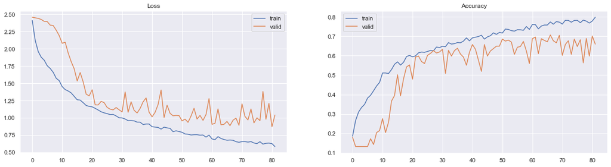

```python
# plot loss and accuracy
plot_hist(history)
```

#### 5.2.1 Model performance

```python
results_1 = metrics_score(model_1, 'CNN 1', X_train, y_train, X_val, y_val)
results_1
```

|  | Model | Accuracy on training set | Accuracy on validation set | Recall on training set | Recal on validation set | Precision on training set | Precision on validation set |
| --- | --- | --- | --- | --- | --- | --- | --- |
| 0 | CNN 1 | 0.778597 | 0.695789 | 0.691579 | 0.622105 | 0.847377 | 0.767532 |

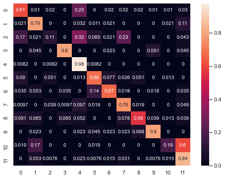

```python
make_confusion_matrix(model_1, X_val, y_val)
```

**Performance Analysis**

## 6 Model Performance Improvement

We are going to try different strategies to improve the model performance:

- Deeper Network Topology
- Image Data Augmentation
- Weighted loss to account for class imbalance

### 6.1 Deeper Network Topology

```python
# Initialize seed for random numbers
np.random.seed(1)
tf.random.set_seed(1)

# Sequential model
model_2 = Sequential()

# Input layer
model_2.add(tf.keras.layers.InputLayer(input_shape=(128,128,3,)))
# Convolution layer
model_2.add(tf.keras.layers.Conv2D(32, kernel_size=(3,3), activation='relu'))
# Max Pool layer
model_2.add(tf.keras.layers.MaxPool2D(pool_size = (2,2)))
# Normalization layer
model_2.add(tf.keras.layers.BatchNormalization())
# 2D Convolution layer
model_2.add(tf.keras.layers.Conv2D(64, kernel_size=(3,3), strides = (1,1), activation='relu'))
# Max Pool layer
model_2.add(tf.keras.layers.MaxPool2D(pool_size = (2,2)))
# Normalization layer
model_2.add(tf.keras.layers.BatchNormalization())
# 2D Convolution layer
model_2.add(tf.keras.layers.Conv2D(128, kernel_size=(3,3), strides = (1,1), activation='relu'))
# Max Pool layer
model_2.add(tf.keras.layers.MaxPool2D(pool_size = (2,2)))
# Normalization layer
model_2.add(tf.keras.layers.BatchNormalization())
# 2D Convolution layer
model_2.add(tf.keras.layers.Conv2D(256, kernel_size=(3,3), strides = (1,1), activation='relu'))
# Max Pool layer
model_2.add(tf.keras.layers.MaxPool2D(pool_size = (2,2)))
# Global Max Pool layer
model_2.add(tf.keras.layers.GlobalMaxPool2D())
# Flatten layer
model_2.add(tf.keras.layers.Flatten())
# Dense layer
model_2.add(tf.keras.layers.Dense(256, activation='relu'))
# Dropout layer
model_2.add(tf.keras.layers.Dropout(0.2))
# Dense layer
model_2.add(tf.keras.layers.Dense(128, activation='relu'))
# Normalization layer
model_2.add(tf.keras.layers.BatchNormalization())
# Output Layer
model_2.add(tf.keras.layers.Dense(12, activation='softmax')) # 12 predicted classes
```

```python
# Compile the model
model_2.compile(optimizer = 'adam', loss = 'categorical_crossentropy',  metrics = ['accuracy', 'Recall', 'Precision'])
```

```python
# Summary of the model
model_2.summary()
```

```
Model: "sequential_1"
_________________________________________________________________
Layer (type)                 Output Shape              Param #
=================================================================
conv2d_1 (Conv2D)            (None, 126, 126, 32)      896
_________________________________________________________________
max_pooling2d_1 (MaxPooling2 (None, 63, 63, 32)        0
_________________________________________________________________
batch_normalization_1 (Batch (None, 63, 63, 32)        128
_________________________________________________________________
conv2d_2 (Conv2D)            (None, 61, 61, 64)        18496
_________________________________________________________________
max_pooling2d_2 (MaxPooling2 (None, 30, 30, 64)        0
_________________________________________________________________
batch_normalization_2 (Batch (None, 30, 30, 64)        256
_________________________________________________________________
conv2d_3 (Conv2D)            (None, 28, 28, 128)       73856
_________________________________________________________________
max_pooling2d_3 (MaxPooling2 (None, 14, 14, 128)       0
_________________________________________________________________
batch_normalization_3 (Batch (None, 14, 14, 128)       512
_________________________________________________________________
conv2d_4 (Conv2D)            (None, 12, 12, 256)       295168
_________________________________________________________________
max_pooling2d_4 (MaxPooling2 (None, 6, 6, 256)         0
_________________________________________________________________
global_max_pooling2d_1 (Glob (None, 256)               0
_________________________________________________________________
flatten_1 (Flatten)          (None, 256)               0
_________________________________________________________________
dense_2 (Dense)              (None, 256)               65792
_________________________________________________________________
dropout_1 (Dropout)          (None, 256)               0
_________________________________________________________________
dense_3 (Dense)              (None, 128)               32896
_________________________________________________________________
batch_normalization_4 (Batch (None, 128)               512
_________________________________________________________________
dense_4 (Dense)              (None, 12)                1548
=================================================================
Total params: 490,060
Trainable params: 489,356
Non-trainable params: 704
_________________________________________________________________
```

```python
print(datetime.now())
```

```
2021-10-14 12:22:00.601956
```

```python
#fitting the model
history=model_2.fit(X_train,
                  y_train,
                  batch_size=64,
                  epochs=100,
                  validation_split=0.2,
                  use_multiprocessing=True,
                  callbacks=[early_stopping])
```

```python
print(datetime.now())
```

```
2021-10-14 12:51:05.789545
```

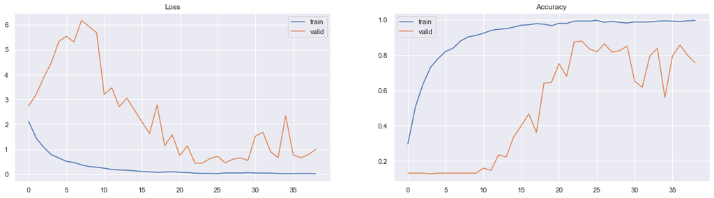

```python
# plot loss and accuracy
plot_hist(history)
```

```python
results_2 = metrics_score(model_2, 'CNN Deeper', X_train, y_train, X_val, y_val)
results_2
```

|  | Model | Accuracy on training set | Accuracy on validation set | Recall on training set | Recal on validation set | Precision on training set | Precision on validation set |
| --- | --- | --- | --- | --- | --- | --- | --- |
| 0 | CNN Deeper | 0.969825 | 0.872632 | 0.967018 | 0.868421 | 0.970764 | 0.882353 |

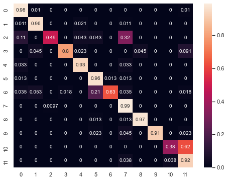

```python
make_confusion_matrix(model_2, X_val, y_val)
```

**Analysis**

### 6.2 Image Data Augmentation

```python
# Initialize seed for random numbers
np.random.seed(1)
tf.random.set_seed(1)

# Sequential model
model_3 = Sequential()

# Input layer
model_3.add(tf.keras.layers.InputLayer(input_shape=(128,128,3,)))

#### Data augmentation

model_3.add(tf.keras.layers.RandomFlip("horizontal", input_shape=(128, 128, 3)))
model_3.add(tf.keras.layers.RandomFlip("vertical", input_shape=(128, 128, 3)))
model_3.add(tf.keras.layers.RandomRotation(0.1))
model_3.add(tf.keras.layers.RandomZoom(0.1))

# Convolution layer
model_3.add(tf.keras.layers.Conv2D(32, kernel_size=(3,3), activation='relu'))
# Max Pool layer
model_3.add(tf.keras.layers.MaxPool2D(pool_size = (2,2)))
# Normalization layer
model_3.add(tf.keras.layers.BatchNormalization())
# 2D Convolution layer
model_3.add(tf.keras.layers.Conv2D(64, kernel_size=(3,3), strides = (1,1), activation='relu'))
# Max Pool layer
model_3.add(tf.keras.layers.MaxPool2D(pool_size = (2,2)))
# Normalization layer
model_3.add(tf.keras.layers.BatchNormalization())
# 2D Convolution layer
model_3.add(tf.keras.layers.Conv2D(128, kernel_size=(3,3), strides = (1,1), activation='relu'))
# Max Pool layer
model_3.add(tf.keras.layers.MaxPool2D(pool_size = (2,2)))
# Normalization layer
model_3.add(tf.keras.layers.BatchNormalization())
# 2D Convolution layer
model_3.add(tf.keras.layers.Conv2D(256, kernel_size=(3,3), strides = (1,1), activation='relu'))
# Max Pool layer
model_3.add(tf.keras.layers.MaxPool2D(pool_size = (2,2)))
# Global Max Pool layer
model_3.add(tf.keras.layers.GlobalMaxPool2D())
# Flatten layer
model_3.add(tf.keras.layers.Flatten())
# Dense layer
model_3.add(tf.keras.layers.Dense(256, activation='relu'))
# Dropout layer
model_3.add(tf.keras.layers.Dropout(0.2))
# Dense layer
model_3.add(tf.keras.layers.Dense(128, activation='relu'))
# Normalization layer
model_3.add(tf.keras.layers.BatchNormalization())
# Output Layer
model_3.add(tf.keras.layers.Dense(12, activation='softmax')) # 12 predicted classes
```

```python
# Compile the model
model_3.compile(optimizer = 'adam', loss = 'categorical_crossentropy',  metrics = ['accuracy', 'Recall', 'Precision'])
```

```python
# Summary of the model
model_3.summary()
```

```
Model: "sequential_2"
_________________________________________________________________
Layer (type)                 Output Shape              Param #
=================================================================
random_flip (RandomFlip)     (None, 128, 128, 3)       0
_________________________________________________________________
random_flip_1 (RandomFlip)   (None, 128, 128, 3)       0
_________________________________________________________________
random_rotation (RandomRotat (None, 128, 128, 3)       0
_________________________________________________________________
random_zoom (RandomZoom)     (None, 128, 128, 3)       0
_________________________________________________________________
conv2d_5 (Conv2D)            (None, 126, 126, 32)      896
_________________________________________________________________
max_pooling2d_5 (MaxPooling2 (None, 63, 63, 32)        0
_________________________________________________________________
batch_normalization_5 (Batch (None, 63, 63, 32)        128
_________________________________________________________________
conv2d_6 (Conv2D)            (None, 61, 61, 64)        18496
_________________________________________________________________
max_pooling2d_6 (MaxPooling2 (None, 30, 30, 64)        0
_________________________________________________________________
batch_normalization_6 (Batch (None, 30, 30, 64)        256
_________________________________________________________________
conv2d_7 (Conv2D)            (None, 28, 28, 128)       73856
_________________________________________________________________
max_pooling2d_7 (MaxPooling2 (None, 14, 14, 128)       0
_________________________________________________________________
batch_normalization_7 (Batch (None, 14, 14, 128)       512
_________________________________________________________________
conv2d_8 (Conv2D)            (None, 12, 12, 256)       295168
_________________________________________________________________
max_pooling2d_8 (MaxPooling2 (None, 6, 6, 256)         0
_________________________________________________________________
global_max_pooling2d_2 (Glob (None, 256)               0
_________________________________________________________________
flatten_2 (Flatten)          (None, 256)               0
_________________________________________________________________
dense_5 (Dense)              (None, 256)               65792
_________________________________________________________________
dropout_2 (Dropout)          (None, 256)               0
_________________________________________________________________
dense_6 (Dense)              (None, 128)               32896
_________________________________________________________________
batch_normalization_8 (Batch (None, 128)               512
_________________________________________________________________
dense_7 (Dense)              (None, 12)                1548
=================================================================
Total params: 490,060
Trainable params: 489,356
Non-trainable params: 704
_________________________________________________________________
```

```python
print(datetime.now())
```

```
2021-10-14 12:51:29.522322
```

```python
#fitting the model
history=model_3.fit(X_train,
                  y_train,
                  batch_size=64,
                  epochs=70,
                  validation_split=0.2,
                  use_multiprocessing=True,
                  callbacks=[early_stopping])
```

```python
print(datetime.now())
```

```
2021-10-14 13:44:43.770144
```

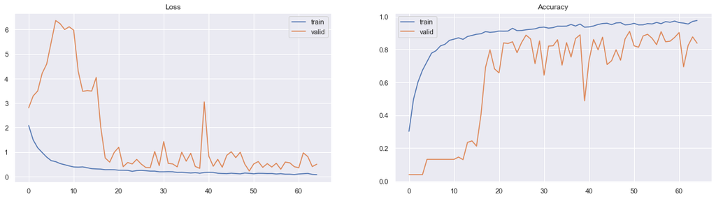

```python
# plot loss and accuracy
plot_hist(history)
```

```python
results_3 = metrics_score(model_3, 'Image Augmentation', X_train, y_train, X_val, y_val)
results_3
```

|  | Model | Accuracy on training set | Accuracy on validation set | Recall on training set | Recal on validation set | Precision on training set | Precision on validation set |
| --- | --- | --- | --- | --- | --- | --- | --- |
| 0 | Image Augmentation | 0.958947 | 0.918947 | 0.958246 | 0.915789 | 0.95993 | 0.924548 |

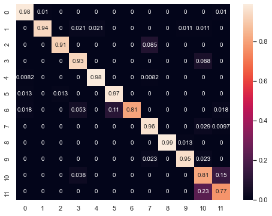

```python
make_confusion_matrix(model_3, X_val, y_val)
```

**Analysis**

### 6.3 Weighted class to account for large class imbalance

```python
# array of labels
a = np.asarray(label.factorize()[0])
# weights for each label
b = 1/pd.DataFrame(a).value_counts(normalize=True)
# clas weights
class_weights = {ix:b[ix] for ix in range(12)}
```

```python
class_weights
```

```
{0: 9.576612903225806,
 1: 10.0,
 2: 20.562770562770563,
 3: 21.493212669683256,
 4: 7.774140752864157,
 5: 12.179487179487179,
 6: 16.550522648083625,
 7: 9.205426356589147,
 8: 12.337662337662339,
 9: 21.493212669683256,
 10: 18.06083650190114,
 11: 7.262996941896024}
```

```python
# Initialize seed for random numbers
np.random.seed(1)
tf.random.set_seed(1)

# Create a copy of the model (with freshly initialized weights)
model_4 = tf.keras.models.clone_model(model_3)
# Compile the model
model_4.compile(optimizer = 'adam', loss = 'categorical_crossentropy',  metrics = ['accuracy', 'Recall', 'Precision'])
```

```python
print(datetime.now())
```

```
2021-10-14 13:45:10.412478
```

```python
#fitting the model
history=model_4.fit(X_train,
                  y_train,
                  batch_size=64,
                  epochs=70,
                  validation_split=0.2,
                  class_weight=class_weights,
                  use_multiprocessing=True,
                  callbacks=[early_stopping])
```

```python
print(datetime.now())
```

```
2021-10-14 14:30:35.765171
```

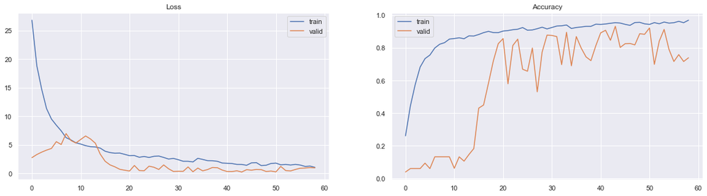

```python
# plot loss and accuracy
plot_hist(history)
```

```python
results_4 = metrics_score(model_4, 'Weighted class', X_train, y_train, X_val, y_val)
results_4
```

|  | Model | Accuracy on training set | Accuracy on validation set | Recall on training set | Recal on validation set | Precision on training set | Precision on validation set |
| --- | --- | --- | --- | --- | --- | --- | --- |
| 0 | Weighted class | 0.96 | 0.907368 | 0.95614 | 0.898947 | 0.96426 | 0.909478 |

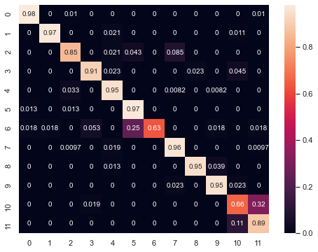

```python
make_confusion_matrix(model_4, X_val, y_val)
```

**Analysis**

- The performance of the weighted class model is slightly lower than the image data augmentation.
- Black-grass images are only classified correctly 66%

## 7 Model performances on test set

Now, we are going to compare all models on test set

```python
# Function to calculate different metric scores of the classification model
def metrics_score_test(model,test,test_y,model_name=''):
    '''
    Inputs:
        model: classifier to predict values of X
        test: Independent features in test sets
        test_y: Dependent variable in test sets
        model_name: Name of the model
    '''

    loss_test, accuracy_test, recall_test, precision_test = model.evaluate(X_test, y_test)
    # Calculate scores and save them in a dictionary
    score_dict = {'Model': model_name,
                  'Accuracy on test set': accuracy_test,
                  'Recall on test set': recall_test,
                  'Precision on test set': precision_test
                 }
    # Create a dataframe with scores
    scores = pd.DataFrame(score_dict,index=[0])

    # return the df
    return scores
```

```python
# Create dataframe with scores on Test dataset for all models
all_scores = pd.concat(
    [metrics_score_test(model_1,X_test,y_test,model_name='1st Model'),
     metrics_score_test(model_2,X_test,y_test,model_name='2nd Model - Deeper Network Topology'),
     metrics_score_test(model_3,X_test,y_test,model_name='3rd Model - Image Data Augmentation'),
     metrics_score_test(model_4,X_test,y_test,model_name='4th Model - Class Imbalance'),
    ],
    axis=0,
    ignore_index=True)
all_scores.sort_values(by=['Accuracy on test set'], ascending=False)
```

|  | Model | Accuracy on test set | Recall on test set | Precision on test set |
| --- | --- | --- | --- | --- |
| 2 | 3rd Model - Image Data Augmentation | 0.916842 | 0.915789 | 0.922588 |
| 3 | 4th Model - Class Imbalance | 0.912632 | 0.910526 | 0.917285 |
| 1 | 2nd Model - Deeper Network Topology | 0.875789 | 0.870526 | 0.885439 |
| 0 | 1st Model | 0.696842 | 0.625263 | 0.775457 |

**Analysis**

- There is a clear trend on how using a deeper network topology and image data augmentation improves the performance of the CNN.
- The first model has Accuracy of 0.69 on test set, but that value increases to 0.87 using an deeper network topology and to 0.92 using also image data augmentation
- The performance of the CNN using class imbalance is very similar than the image data augmentation.
- Now, we are going ti use our third model (Image Data Augmentation) to calculate the confusion matrix on test set

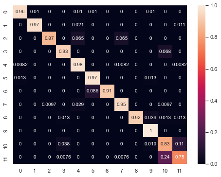

```python
make_confusion_matrix(model_3, X_test, y_test)
```

- The Image Data Augmentation model presents very good performance in training, validation and test sets.

## 8 Conclusion and key takeaways

The main conclusions are:

- With this project we were able to classify plant's species from a photo. The accuracy is very good in training, validation and test sets, 0.95/0.91/0.92 respectively
- We improve the performance of the model using several strategies that show being effective in Image Classification problems
  - Using a deeper network topology
  - Using image data augmentation
  - Using weighted class to account for class imbalance
- The model correctly classifies the different images
- However, some Black-grass and Loose Silky-bent images were not properly identified. There are a couple of reasons:
  - The Black-grass class has around 250 images compared with other classes with more than 600 images. Our data set is very unbalanced
  - Both plants are similar, and the Neural Network is not being able to create a good separation between the two classes